# Survival Analysis for subtypes of HGG/DMG

C. Savonen for ALSF CCDL, Krutika Gaonkar for D3B

2019

**Purpose:**

Runs survival analysis models for subtypes of Diffuse astrocytic and oligodendroglial tumors. This module was most recently run on release-v17-20200908/pbta-histologies.tsv

## Usage

Uses a wrapper function (`survival_analysis`) from utils folder.

## Setup

#### Packages and functions

Read in set up script.

```r
# This script contains a wrapper function that can conduct the survival analyses
source(file.path("util", "survival_models.R"))
# Magrittr pipe
`%>%` <- dplyr::`%>%`
```

#### Set up files and directories

Set up output directories.

```r
data_dir <- file.path("..", "..", "data")
results_dir <- "results"
plots_dir <- "plots"
```

Make output directories.

```r
if (!dir.exists(results_dir)) {
  dir.create(results_dir)
}
if (!dir.exists(plots_dir)) {
  dir.create(plots_dir)
}
```

Declare input file paths and useful variables

```r
metadata_file <- file.path(data_dir, "pbta-histologies.tsv")
independent_primary_file <- file.path(
  data_dir,
  "independent-specimens.wgswxs.primary.tsv")

# Number of participants required to consider a subtype in survival analysis
n_participants <- 3
```

Declare output file paths for HGG/DMG all subtypes.

```r
kap_meier_plot_file <- file.path(plots_dir, "survival_curve_DMG_H3_K28_v_HGG_H3_wildtype.pdf")
kap_meier_model_file <- file.path(results_dir, "survival_model_DMG_H3_K28_v_HGG_H3_wildtype.tsv")
```

## Import the metadata

```r
# choose Diffuse astrocytic and oligodendroglial tumor samples
# remove RNA-Seq because subtyping in HGG is from DNA abberations and samples where only RNA-Seq is available cannot be subtyped
# remove cell-lines from this analysis as well
metadata <- readr::read_tsv(
  metadata_file,
  col_types = readr::cols(
    molecular_subtype = readr::col_character())) %>%
  dplyr::filter(
    experimental_strategy != "RNA-Seq" &
      broad_histology == "Diffuse astrocytic and oligodendroglial tumor" &
      composition=="Solid Tissue") %>%
  as.data.frame()
```

#### Using independent_primary if multiple subtypes per patient are found

This way we subset the metadata to 1 single primary sample per patient ID

```r
# Patients with multiple different molecular subtype might affect downstream analysis for survival so using independent_primary sample set which has 1-1 sample-patient matches
independent_primary <- readr::read_tsv(independent_primary_file)
# select only independent primary bs_ids to get overall survival
metadata <- metadata %>%
  dplyr::filter(Kids_First_Biospecimen_ID %in%
                  independent_primary$Kids_First_Biospecimen_ID)

# find molecular subtypes which have more than n_participants (3) participants
filter_molecular_subtype <- metadata %>% group_by(molecular_subtype) %>% dplyr::tally() %>% dplyr::filter(n>n_participants)

# select only molecular_subtypes that have more than n_participants (3) participants
metadata <- metadata %>%
  dplyr::filter(molecular_subtype %in%
                  filter_molecular_subtype$molecular_subtype)
```

## Kaplan-Meier for all HGG/DMG subtypes

The [Kaplan-Meier](https://www.ncbi.nlm.nih.gov/pmc/articles/PMC3059453/) survival curve shows the probability of survival over time.

```r
kap_fit <- survival_analysis(metadata,
  ind_var = "molecular_subtype",
  test = "kap.meier",
  metadata_sample_col = "Kids_First_Biospecimen_ID"
)
```

```
Note: Using an external vector in selections is ambiguous.
ℹ Use `all_of(ind_var)` instead of `ind_var` to silence this message.
ℹ See <https://tidyselect.r-lib.org/reference/faq-external-vector.html>.
```

```
Testing model: survival::Surv(OS_days, OS_status) ~ molecular_subtype with kap.meier
```

```r
# median and 0.95CI survival days
kap_fit$model
```

```
Call: survfit(formula = survival::Surv(OS_days, OS_status) ~ molecular_subtype,
    data = ind_var_df)

   6 observations deleted due to missingness
                                               n events median 0.95LCL
molecular_subtype=DMG, H3 K28                 13     13    536     355
molecular_subtype=DMG, H3 K28, TP53 activated  7      7    294      18
molecular_subtype=DMG, H3 K28, TP53 loss      26     26    275     244
molecular_subtype=HGG, H3 wildtype            12      7    582     375
molecular_subtype=HGG, H3 wildtype, TP53 loss  8      8    392     349
                                              0.95UCL
molecular_subtype=DMG, H3 K28                      NA
molecular_subtype=DMG, H3 K28, TP53 activated      NA
molecular_subtype=DMG, H3 K28, TP53 loss          394
molecular_subtype=HGG, H3 wildtype                 NA
molecular_subtype=HGG, H3 wildtype, TP53 loss      NA
```

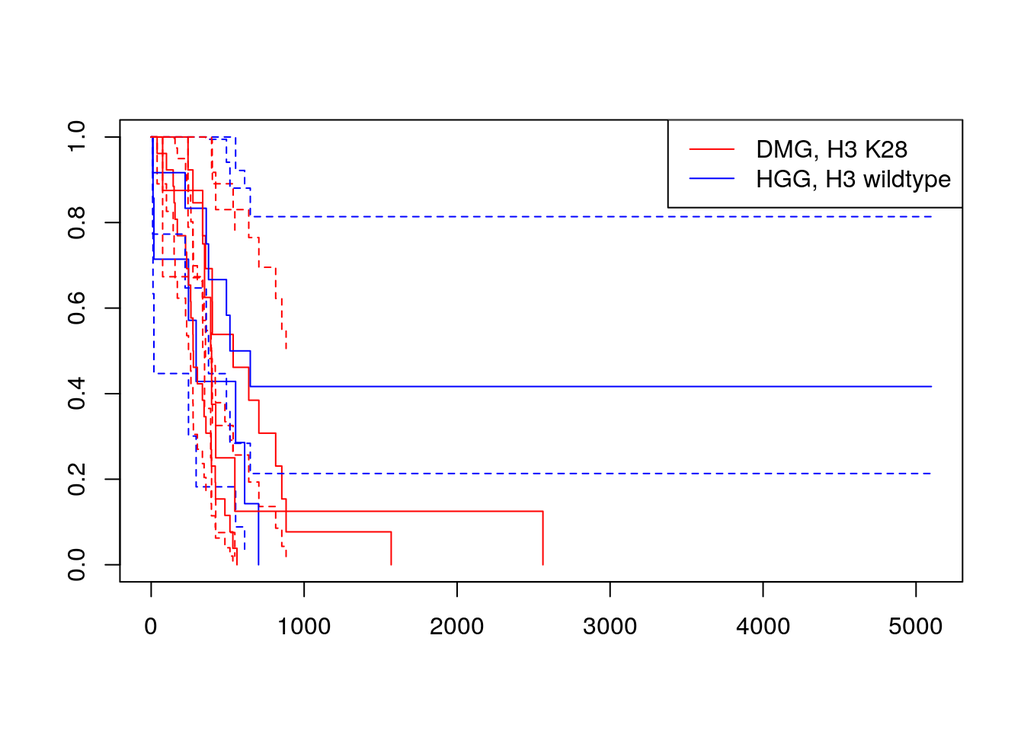

```r
plot(kap_fit$model, mark.time=FALSE, conf.int=TRUE, col=c("red", "blue"))
legend("topright", legend=c("DMG, H3 K28", "HGG, H3 wildtype"),col=c("red", "blue"), lty=1)
```

`survminer` package comes with a convenient plotting function which uses `ggplot2` arguments. It requires the original Kaplain-Meier `survfit` object, so we will extract that with `$model`.

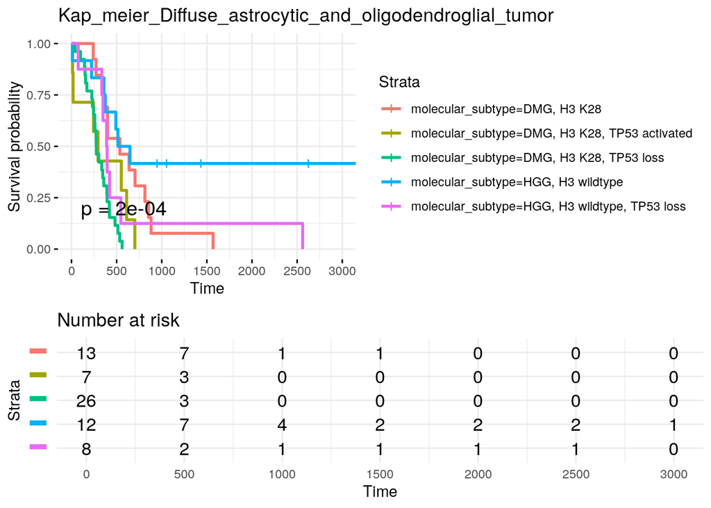

```r
surv_plot <- survminer::ggsurvplot(kap_fit$model,
  pval = TRUE,
  data = kap_fit$original_data,
  risk.table = TRUE,
  xlim = c(0, 3000),
  break.time.by = 500,
  ggtheme = theme_minimal(),
  risk.table.y.text.col = TRUE,
  risk.table.y.text = FALSE
)

surv_plot$plot <- surv_plot$plot +
  ggtitle(paste0("Kap_meier_Diffuse_astrocytic_and_oligodendroglial_tumor")) +
  theme(legend.position = "right")

# Make this plot a combined plot
surv_plot_all_subtype <-
  cowplot::plot_grid(surv_plot[[1]], surv_plot[[2]], nrow = 2,
                     rel_heights = c(3, 2))

# Print it out here
surv_plot_all_subtype
```

Save the plot to a file.

```r
# We can save the plot like a normal ggplot
cowplot::save_plot(filename = kap_meier_plot_file, plot = surv_plot_all_subtype)
# Let's save the model for CI and median survial as well
readr::write_tsv(surv_median(kap_fit$model), kap_meier_model_file)
```